[figure not shown]

# Проект: Анализ резюме из HeadHunter

```python
import pandas as pd
import numpy as np
import matplotlib.pyplot as plt
import seaborn as sns
import plotly.express as px
```

# Исследование структуры данных

1. Прочитайте данные с помощью библиотеки Pandas. Совет: перед чтением обратите внимание на разделитель внутри файла.

```python
HeadHunter_data = pd.read_csv('data/dst-3.0_16_1_hh_database.csv', sep=';')
display(HeadHunter_data.shape)
display(f'Количество строк:{HeadHunter_data.shape[0]}, Количество столбцов:{HeadHunter_data.shape[1]}')
```

```
(44744, 12)
```

```
'Количество строк:44744, Количество столбцов:12'
```

1. Выведите несколько первых (последних) строк таблицы, чтобы убедиться в том, что ваши данные не повреждены. Ознакомьтесь с признаками и их структурой.

```python
display(HeadHunter_data.head())
display(HeadHunter_data.tail())
```

|  | Пол, возраст | ЗП | Ищет работу на должность: | Город, переезд, командировки | Занятость | График | Опыт работы | Последнее/нынешнее место работы | Последняя/нынешняя должность | Образование и ВУЗ | Обновление резюме | Авто |
| --- | --- | --- | --- | --- | --- | --- | --- | --- | --- | --- | --- | --- |
| 0 | Мужчина , 39 лет , родился 27 ноября 1979 | 29000 руб. | Системный администратор | Советск (Калининградская область) , не готов к... | частичная занятость, проектная работа, полная ... | гибкий график, полный день, сменный график, ва... | Опыт работы 16 лет 10 месяцев Август 2010 — п... | МАОУ "СОШ № 1 г.Немана" | Системный администратор | Неоконченное высшее образование 2000 Балтийск... | 16.04.2019 15:59 | Имеется собственный автомобиль |
| 1 | Мужчина , 60 лет , родился 20 марта 1959 | 40000 руб. | Технический писатель | Королев , не готов к переезду , готов к редким... | частичная занятость, проектная работа, полная ... | гибкий график, полный день, сменный график, уд... | Опыт работы 19 лет 5 месяцев Январь 2000 — по... | Временный трудовой коллектив | Менеджер проекта, Аналитик, Технический писатель | Высшее образование 1981 Военно-космическая ак... | 12.04.2019 08:42 | Не указано |
| 2 | Женщина , 36 лет , родилась 12 августа 1982 | 20000 руб. | Оператор | Тверь , не готова к переезду , не готова к ком... | полная занятость | полный день | Опыт работы 10 лет 3 месяца Октябрь 2004 — Де... | ПАО Сбербанк | Кассир-операционист | Среднее специальное образование 2002 Профессио... | 16.04.2019 08:35 | Не указано |
| 3 | Мужчина , 38 лет , родился 25 июня 1980 | 100000 руб. | Веб-разработчик (HTML / CSS / JS / PHP / базы ... | Саратов , не готов к переезду , готов к редким... | частичная занятость, проектная работа, полная ... | гибкий график, удаленная работа | Опыт работы 18 лет 9 месяцев Август 2017 — Ап... | OpenSoft | Инженер-программист | Высшее образование 2002 Саратовский государст... | 08.04.2019 14:23 | Не указано |
| 4 | Женщина , 26 лет , родилась 3 марта 1993 | 140000 руб. | Региональный менеджер по продажам | Москва , не готова к переезду , готова к коман... | полная занятость | полный день | Опыт работы 5 лет 7 месяцев Региональный мене... | Мармелад | Менеджер по продажам | Высшее образование 2015 Кгу Психологии и педаг... | 22.04.2019 10:32 | Не указано |

|  | Пол, возраст | ЗП | Ищет работу на должность: | Город, переезд, командировки | Занятость | График | Опыт работы | Последнее/нынешнее место работы | Последняя/нынешняя должность | Образование и ВУЗ | Обновление резюме | Авто |
| --- | --- | --- | --- | --- | --- | --- | --- | --- | --- | --- | --- | --- |
| 44739 | Мужчина , 30 лет , родился 17 января 1989 | 50000 руб. | Финансист, аналитик, экономист, бухгалтер, мен... | Тверь , готов к переезду (Москва, Химки) , гот... | полная занятость | полный день, удаленная работа | Опыт работы 7 лет 7 месяцев Финансист, аналит... | ООО "IAS" (независимый участник объединения Ru... | Руководитель субгруппы | Высшее образование 2015 Московский гуманитарн... | 22.04.2019 12:32 | Не указано |
| 44740 | Мужчина , 27 лет , родился 5 марта 1992 | 39000 руб. | Системный администратор, IT-специалист | Липецк , готов к переезду , готов к командировкам | проектная работа, частичная занятость, полная ... | удаленная работа, гибкий график, полный день, ... | Опыт работы 7 лет Системный администратор, IT... | ИП Пестрецов | Предприниматель | Высшее образование (Бакалавр) 2016 Воронежски... | 22.04.2019 13:11 | Не указано |
| 44741 | Женщина , 48 лет , родилась 26 декабря 1970 | 40000 руб. | Аналитик данных, Математик | Челябинск , готова к переезду , готова к редки... | полная занятость | полный день, удаленная работа | Опыт работы 21 год 5 месяцев Январь 1998 — по... | ОАО «ЧМК», Исследовательско-Технологический Це... | Начальник группы аналитики | Высшее образование 2000 Южно-Уральский госуда... | 09.04.2019 05:07 | Не указано |
| 44742 | Мужчина , 24 года , родился 6 октября 1994 | 20000 руб. | Контент-менеджер | Тамбов , не готов к переезду , не готов к кома... | частичная занятость, полная занятость | удаленная работа | Опыт работы 3 года 10 месяцев Контент-менедже... | IQ-Maxima | Менеджер проектов | Высшее образование 2015 Тамбовский государств... | 26.04.2019 14:25 | Имеется собственный автомобиль |
| 44743 | Мужчина , 38 лет , родился 25 апреля 1980 | 120000 руб. | Руководитель проекта | Москва , не готов к переезду , не готов к кома... | полная занятость | полный день | Опыт работы 15 лет 10 месяцев Руководитель пр... | ПАО ГК ТНС энерго | Руководитель отдела технической поддержки | Высшее образование 1997 Южно-Российский госуд... | 05.07.2018 20:15 | Не указано |

1. Выведите основную информацию о числе непустых значений в столбцах и их типах в таблице.
1. Обратите внимание на информацию о числе непустых значений.

```python
display(HeadHunter_data.info())
```

```
<class 'pandas.core.frame.DataFrame'>
RangeIndex: 44744 entries, 0 to 44743
Data columns (total 12 columns):
 #   Column                           Non-Null Count  Dtype
---  ------                           --------------  -----
 0   Пол, возраст                     44744 non-null  object
 1   ЗП                               44744 non-null  object
 2   Ищет работу на должность:        44744 non-null  object
 3   Город, переезд, командировки     44744 non-null  object
 4   Занятость                        44744 non-null  object
 5   График                           44744 non-null  object
 6   Опыт работы                      44576 non-null  object
 7   Последнее/нынешнее место работы  44743 non-null  object
 8   Последняя/нынешняя должность     44742 non-null  object
 9   Образование и ВУЗ                44744 non-null  object
 10  Обновление резюме                44744 non-null  object
 11  Авто                             44744 non-null  object
dtypes: object(12)
memory usage: 4.1+ MB
```

```
None
```

1. Выведите основную статистическую информацию о столбцах.

```python
display(HeadHunter_data.describe())
```

|  | Пол, возраст | ЗП | Ищет работу на должность: | Город, переезд, командировки | Занятость | График | Опыт работы | Последнее/нынешнее место работы | Последняя/нынешняя должность | Образование и ВУЗ | Обновление резюме | Авто |
| --- | --- | --- | --- | --- | --- | --- | --- | --- | --- | --- | --- | --- |
| count | 44744 | 44744 | 44744 | 44744 | 44744 | 44744 | 44576 | 44743 | 44742 | 44744 | 44744 | 44744 |
| unique | 16003 | 690 | 14929 | 10063 | 38 | 47 | 44413 | 30214 | 16927 | 40148 | 18838 | 2 |
| top | Мужчина , 32 года , родился 17 сентября 1986 | 50000 руб. | Системный администратор | Москва , не готов к переезду , не готов к кома... | полная занятость | полный день | Опыт работы 10 лет 8 месяцев Апрель 2018 — по... | Индивидуальное предпринимательство / частная п... | Системный администратор | Высшее образование 1987 Военный инженерный Кра... | 07.05.2019 09:50 | Не указано |
| freq | 18 | 4064 | 3099 | 1261 | 30026 | 22727 | 3 | 935 | 2062 | 4 | 25 | 32268 |

# Преобразование данных

1. Начнем с простого - с признака **"Образование и ВУЗ"**. Его текущий формат это: **<Уровень образования год выпуска ВУЗ специальность...>**. Например:
- Высшее образование 2016 Московский авиационный институт (национальный исследовательский университет)...
- Неоконченное высшее образование 2000 Балтийская государственная академия рыбопромыслового флота… Нас будет интересовать только уровень образования.

Создайте с помощью функции-преобразования новый признак **"Образование"**, который должен иметь 4 категории: "высшее", "неоконченное высшее", "среднее специальное" и "среднее".

Выполните преобразование, ответьте на контрольные вопросы и удалите признак "Образование и ВУЗ".

Совет: обратите внимание на структуру текста в столбце **"Образование и ВУЗ"**. Гарантируется, что текущий уровень образования соискателя всегда находится в первых 2ух слов и начинается с заглавной буквы. Воспользуйтесь этим.

*Совет: проверяйте полученные категории, например, с помощью метода unique()*

```python
HeadHunter_data_df = HeadHunter_data.copy()

HeadHunter_data_df['Образование'] = HeadHunter_data_df['Образование и ВУЗ'].apply(lambda x: 'высшее' if x[0] == 'В' else x)
HeadHunter_data_df['Образование'] = HeadHunter_data_df['Образование'].apply(lambda x: 'неоконченное высшее' if x[0] == 'Н' else x)
HeadHunter_data_df['Образование'] = HeadHunter_data_df['Образование'].apply(lambda x: 'среднее специальное' if x[0:9] == 'Среднее с' else x)
HeadHunter_data_df['Образование'] = HeadHunter_data_df['Образование'].apply(lambda x: 'среднее' if x[0:9] == 'Среднее о' else x)

HeadHunter_data_df = HeadHunter_data_df.drop('Образование и ВУЗ', axis=1)
print('Количество соискателей, которые имеет средний уровень образования:', HeadHunter_data_df[HeadHunter_data_df['Образование'] == 'среднее'].shape[0])
```

```
Количество соискателей, которые имеет средний уровень образования: 559
```

1. Теперь нас интересует столбец **"Пол, возраст"**. Сейчас он представлен в формате **<Пол , возраст , дата рождения >**. Например:
- Мужчина , 39 лет , родился 27 ноября 1979
- Женщина , 21 год , родилась 13 января 2000 Как вы понимаете, нам необходимо выделить каждый параметр в отдельный столбец.

Создайте два новых признака **"Пол"** и **"Возраст"**. При этом важно учесть:

- Признак пола должен иметь 2 уникальных строковых значения: 'М' - мужчина, 'Ж' - женщина.
- Признак возраста должен быть представлен целыми числами.

Выполните преобразование, ответьте на контрольные вопросы и удалите признак **"Пол, возраст"** из таблицы.

*Совет: обратите внимание на структуру текста в столбце, в части на то, как разделены параметры пола, возраста и даты рождения между собой - символом ' , '. Гарантируется, что структура одинакова для всех строк в таблице. Вы можете воспользоваться этим.*

```python
HeadHunter_data_df = HeadHunter_data_df.copy()

HeadHunter_data_df['Пол'] = HeadHunter_data_df['Пол, возраст'].apply(lambda x: 'Ж' if x[0] == 'Ж' else x)
HeadHunter_data_df['Пол'] = HeadHunter_data_df['Пол'].apply(lambda x: 'М' if x[0] == 'М' else x)
display(round(HeadHunter_data_df['Пол'].value_counts(normalize=True)*100, 2))

def get_age(arg):
    year_key_words = ['год', 'лет', 'года']
    args_splited = arg.split(' ')
    year = 0

    for i in range(len(args_splited)):
        if args_splited[i] in year_key_words:
            year = args_splited[i-2] + args_splited[i-1]
    return int(year)

HeadHunter_data_df['Возраст'] = HeadHunter_data_df['Пол, возраст'].apply(get_age)
HeadHunter_data_df = HeadHunter_data_df.drop('Пол, возраст', axis=1)
print('Cредний возраст соискателей:', HeadHunter_data_df['Возраст'].mean().round(1))
```

```
М    80.93
Ж    19.07
Name: Пол, dtype: float64
```

```
Cредний возраст соискателей: 32.2
```

1. Следующим этапом преобразуем признак **"Опыт работы"**. Его текущий формат - это: **<Опыт работы: n лет m месяцев, периоды работы в различных компаниях…>**.

Из столбца нам необходимо выделить общий опыт работы соискателя в месяцах, новый признак назовем "Опыт работы (месяц)"

Для начала обсудим условия решения задачи:

- Во-первых, в данном признаке есть пропуски. Условимся, что если мы встречаем пропуск, оставляем его как есть (функция-преобразование возвращает NaN)
- Во-вторых, в данном признаке есть скрытые пропуски. Для некоторых соискателей в столбце стоит значения "Не указано". Их тоже обозначим как NaN (функция-преобразование возвращает NaN)
- В-третьих, нас не интересует информация, которая описывается после указания опыта работы (периоды работы в различных компаниях)
- В-четвертых, у нас есть проблема: опыт работы может быть представлен только в годах или только месяцах. Например, можно встретить следующие варианты:
  - Опыт работы 3 года 2 месяца…
  - Опыт работы 4 года…
  - Опыт работы 11 месяцев…
  - Учитывайте эту особенность в вашем коде

Учитывайте эту особенность в вашем коде

В результате преобразования у вас должен получиться столбец, содержащий информацию о том, сколько месяцев проработал соискатель. Выполните преобразование, ответьте на контрольные вопросы и удалите столбец **"Опыт работы"** из таблицы.

```python
HeadHunter_data_df = HeadHunter_data_df.copy()

def get_experience(arg):
    if arg is np.nan or arg == 'Не указано':
        return None
    arg = str(arg)
    month_key_words = ['месяц', 'месяцев', 'месяца']
    year_key_words = ['год', 'лет', 'года']
    args_splited = arg.split(' ')[:7]
    month = 0
    year = 0

    for i in range(len(args_splited)):
        if args_splited[i] in month_key_words:
            month = args_splited[i-1]
        if args_splited[i] in year_key_words:
            year = args_splited[i-1]
    return int(year)*12 + int(month)

HeadHunter_data_df['Опыт работы (месяц)'] = HeadHunter_data_df['Опыт работы'].apply(get_experience)
HeadHunter_data_df = HeadHunter_data_df.drop('Опыт работы', axis=1)
print('Медианный опыт работы (в месяцах):', round(HeadHunter_data_df['Опыт работы (месяц)'].median()))
```

```
Медианный опыт работы (в месяцах): 100
```

1. Хорошо идем! Следующий на очереди признак "Город, переезд, командировки". Информация в нем представлена в следующем виде: **<Город , (метро) , готовность к переезду (города для переезда) , готовность к командировкам>**. В скобках указаны необязательные параметры строки. Например, можно встретить следующие варианты:
- Москва , не готов к переезду , готов к командировкам
- Москва , м. Беломорская , не готов к переезду, не готов к командировкам
- Воронеж , готов к переезду (Сочи, Москва, Санкт-Петербург) , готов к командировкам

Создадим отдельные признаки **"Город"**, **"Готовность к переезду"**, **"Готовность к командировкам"**. При этом важно учесть:

- Признак **"Город"** должен содержать только 4 категории: "Москва", "Санкт-Петербург" и "город-миллионник" (их список ниже), остальные обозначьте как "другие".

  Список городов-миллионников:

  `million_cities = ['Новосибирск', 'Екатеринбург','Нижний Новгород','Казань', 'Челябинск','Омск', 'Самара', 'Ростов-на-Дону', 'Уфа', 'Красноярск', 'Пермь', 'Воронеж','Волгоград']` Инфорация о метро, рядом с которым проживает соискатель нас не интересует.
- Признак **"Готовность к переезду"** должен иметь два возможных варианта: True или False. Обратите внимание, что возможны несколько вариантов описания готовности к переезду в признаке "Город, переезд, командировки". Например:
  - … , готов к переезду , …
  - … , не готова к переезду , …
  - … , готова к переезду (Москва, Санкт-Петербург, Ростов-на-Дону)
  - … , хочу переехать (США) , …

    Нас интересует только сам факт возможности или желания переезда.
- Признак **"Готовность к командировкам"** должен иметь два возможных варианта: True или False. Обратите внимание, что возможны несколько вариантов описания готовности к командировкам в признаке "Город, переезд, командировки". Например:
  - … , готов к командировкам , …
  - … , готова к редким командировкам , …
  - … , не готов к командировкам , …

    Нас интересует только сам факт готовности к командировке.

    Еще один важный факт: при выгрузки данных у некоторых соискателей "потерялась" информация о готовности к командировкам. Давайте по умолчанию будем считать, что такие соискатели не готовы к командировкам.

Выполните преобразования и удалите столбец **"Город, переезд, командировки"** из таблицы.

*Совет: обратите внимание на то, что структура текста может меняться в зависимости от указания ближайшего метро. Учите это, если будете использовать порядок слов в своей программе.*

```python
HeadHunter_data_df = HeadHunter_data_df.copy()

def get_city(city):
    million_cities = ['Новосибирск', 'Екатеринбург','Нижний Новгород','Казань', 'Челябинск','Омск', 'Самара', 'Ростов-на-Дону', 'Уфа', 'Красноярск', 'Пермь', 'Воронеж','Волгоград']
    city = str(city)
    city_splited = city.split(' ')[0]

    if city_splited in million_cities:
        return "город-миллионник"
    if city_splited == "Москва" or city_splited == "Санкт-Петербург":
        return city_splited
    else:
        return "другие"

def get_removal(removal):
    if ('не готов к переезду' in removal) or ('не готова к переезду' in removal):
        return False
    elif 'хочу' in removal:
        return True
    else:
        return True

def get_trip(trip):
    trip = str(trip)
    trip_splited = trip.split(' ')

    if trip_splited[-4] == 'не' or trip_splited[-3] == 'не':
        return False
    else:
        return True

HeadHunter_data_df['Город'] = HeadHunter_data_df['Город, переезд, командировки'].apply(get_city)
HeadHunter_data_df['Готовность к переезду'] = HeadHunter_data_df['Город, переезд, командировки'].apply(get_removal)
HeadHunter_data_df['Готовность к командировкам'] = HeadHunter_data_df['Город, переезд, командировки'].apply(get_trip)

HeadHunter_data_df = HeadHunter_data_df.drop('Город, переезд, командировки', axis=1)
print(round(HeadHunter_data_df['Город'].value_counts(normalize=True)['Санкт-Петербург'] * 100), 'процентов соискателей живут в Санкт-Петербурге')
print(round(HeadHunter_data_df[
    HeadHunter_data_df['Готовность к переезду'] & HeadHunter_data_df['Готовность к командировкам']
].shape[0] / HeadHunter_data_df.shape[0] *100), 'процентов соискателей готовы одновременно и к переездам, и к командировкам')
```

```
11 процентов соискателей живут в Санкт-Петербурге
32 процентов соискателей готовы одновременно и к переездам, и к командировкам
```

1. Рассмотрим поближе признаки **"Занятость"** и **"График"**. Сейчас признаки представляют собой набор категорий желаемой занятости (полная занятость, частичная занятость, проектная работа, волонтерство, стажировка) и желаемого графика работы (полный день, сменный график, гибкий график, удаленная работа, вахтовый метод). На сайте hh.ru соискатель может указывать различные комбинации данных категорий, например:
- полная занятость, частичная занятость
- частичная занятость, проектная работа, волонтерство
- полный день, удаленная работа
- вахтовый метод, гибкий график, удаленная работа, полная занятость

Такой вариант признаков имеет множество различных комбинаций, а значит множество уникальных значений, что мешает анализу. Нужно это исправить!

Давайте создадим признаки-мигалки для каждой категории: если категория присутствует в списке желаемых соискателем, то в столбце на месте строки рассматриваемого соискателя ставится True, иначе - False.

Такой метод преобразования категориальных признаков называется One Hot Encoding и его схема представлена на рисунке ниже:

[figure not shown]

Выполните данное преобразование для признаков "Занятость" и "График", ответьте на контрольные вопросы, после чего удалите их из таблицы

```python
data_df = HeadHunter_data_df.copy()

employment_list = ['полная занятость', 'частичная занятость', 'проектная работа', 'стажировка', 'волонтерство']
schedule_list = ['полный день', 'сменный график', 'гибкий график', 'удаленная работа', 'вахтовый метод']

data_df['temp_sum'] = data_df['Занятость'] + ' ' + data_df['График']

for i in employment_list:
    data_df[i] = data_df['temp_sum'].apply(lambda x: True if i in x else False)

for i in schedule_list:
    data_df[i] = data_df['temp_sum'].apply(lambda x: True if i in x else False)

HeadHunter_data_df = data_df
HeadHunter_data_df = HeadHunter_data_df.drop(['temp_sum', 'Занятость', 'График'], axis=1)
print('Количество людей, которые ищут проектную работу и волонтёрство:', HeadHunter_data_df[(HeadHunter_data_df['проектная работа'] == True) & (HeadHunter_data_df['волонтерство'] == True)].shape[0])
print('Количество людей, которые хотят работать вахтовым методом и с гибким графиком:', HeadHunter_data_df[(HeadHunter_data_df['вахтовый метод'] == True) & (HeadHunter_data_df['гибкий график'] == True)].shape[0])
```

```
Количество людей, которые ищут проектную работу и волонтёрство: 436
Количество людей, которые хотят работать вахтовым методом и с гибким графиком: 2311
```

1. (2 балла) Наконец, мы добрались до самого главного и самого важного - признака заработной платы **"ЗП"**. В чем наша беда? В том, что помимо желаемой заработной платы соискатель указывает валюту, в которой он бы хотел ее получать, например:
- 30000 руб.
- 50000 грн.
- 550 USD

Нам бы хотелось видеть заработную плату в единой валюте, например, в рублях. Возникает вопрос, а где взять курс валют по отношению к рублю?

На самом деле язык Python имеет в арсенале огромное количество возможностей получения данной информации, от обращения к API Центробанка, до использования специальных библиотек, например pycbrf. Однако, это не тема нашего проекта.

Поэтому мы пойдем в лоб: обратимся к специальным интернет-ресурсам для получения данных о курсе в виде текстовых файлов. Например, MDF.RU, данный ресурс позволяет удобно экспортировать данные о курсах различных валют и акций за указанные периоды в виде csv файлов. Мы уже сделали выгрузку курсов валют, которые встречаются в наших данных за период с 29.12.2017 по 05.12.2019. Скачать ее вы можете **на платформе**

Создайте новый DataFrame из полученного файла. В полученной таблице нас будут интересовать столбцы:

- "currency" - наименование валюты в ISO кодировке,
- "date" - дата,
- "proportion" - пропорция,
- "close" - цена закрытия (последний зафиксированный курс валюты на указанный день).

Перед вами таблица соответствия наименований иностранных валют в наших данных и их общепринятых сокращений, которые представлены в нашем файле с курсами валют. Пропорция - это число, за сколько единиц валюты указан курс в таблице с курсами. Например, для казахстанского тенге курс на 20.08.2019 составляет 17.197 руб. за 100 тенге, тогда итоговый курс равен - 17.197 / 100 = 0.17197 руб за 1 тенге. Воспользуйтесь этой информацией в ваших преобразованиях.

[figure not shown]

Осталось только понять, откуда брать дату, по которой определяется курс? А вот же она - в признаке **"Обновление резюме"**, в нем содержится дата и время, когда соискатель выложил текущий вариант своего резюме. Нас интересует только дата, по ней бы и будем сопоставлять курсы валют.

Теперь у нас есть вся необходимая информация для того, чтобы создать признак "ЗП (руб)" - заработная плата в рублях.

После ответа на контрольные вопросы удалите исходный столбец заработной платы "ЗП" и все промежуточные столбцы, если вы их создавали.

Итак, давайте обсудим возможный алгоритм преобразования:

1. Перевести признак "Обновление резюме" из таблицы с резюме в формат datetime и достать из него дату. В тот же формат привести признак "date" из таблицы с валютами.
2. Выделить из столбца "ЗП" сумму желаемой заработной платы и наименование валюты, в которой она исчисляется. Наименование валюты перевести в стандарт ISO согласно с таблицей выше.
3. Присоединить к таблице с резюме таблицу с курсами по столбцам с датой и названием валюты (подумайте, какой тип объединения надо выбрать, чтобы в таблице с резюме сохранились данные о заработной плате, изначально представленной в рублях). Значение close для рубля заполнить единицей 1 (курс рубля самого к себе)
4. Умножить сумму желаемой заработной платы на присоединенный курс валюты (close) и разделить на пропорцию (обратите внимание на пропуски после объединения в этих столбцах), результат занести в новый столбец "ЗП (руб)".

```python
income = HeadHunter_data_df.copy()

ExchangeRates = pd.read_csv('data/ExchangeRates.csv')
ExchangeRates['date'] = pd.to_datetime(ExchangeRates['date'], dayfirst=True)
ExchangeRates.drop(['per','time','vol'],axis=1, inplace=True)

income['Обновление резюме'] = pd.to_datetime(income['Обновление резюме']).dt.date
income['Обновление резюме'] = pd.to_datetime(income['Обновление резюме'])
income['Сумма зарплаты'] =  income['ЗП'].apply(lambda x: x.split(' ')[0])
income['Наименование валюты'] = income['ЗП'].apply(lambda x: x.split(' ')[1])

def get_currency(arg):
    currency_dict = {
        'USD': 'USD', 'KZT': 'KZT',
        'грн': 'UAH', 'белруб': 'BYN',
        'EUR': 'EUR', 'KGS': 'KGS',
        'сум': 'UZS', 'AZN': 'AZN'
    }
    curr = arg.replace('.', '')

    if curr == 'руб':
        return 'RUB'
    else:
        return currency_dict[curr]

income['Наименование валюты'] = income['Наименование валюты'].apply(get_currency)

merged = income.merge(
    ExchangeRates,
    left_on=['Обновление резюме', 'Наименование валюты'],
    right_on=['date', 'currency'],
    how='left'
)
merged['close'] = merged['close'].fillna(1)
merged['proportion'] = merged['proportion'].fillna(1)
merged['Сумма зарплаты'] = merged['Сумма зарплаты'].astype('float')
merged['ЗП (руб)'] = merged['Сумма зарплаты']*merged['close']/merged['proportion']
merged.drop(['ЗП', 'Сумма зарплаты', 'Наименование валюты', 'currency', 'date', 'close', 'proportion' ], axis=1, inplace=True)
merged['Обновление резюме'] = merged['Обновление резюме'].astype('object')
print('Желаемая медианная заработная плата соискателей:', merged['ЗП (руб)'].median(), 'т.руб')
```

```
Желаемая медианная заработная плата соискателей: 59000.0 т.руб
```

# Исследование зависимостей в данных

1. Постройте распределение признака **"Возраст"**. Опишите распределение, отвечая на следующие вопросы: чему равна мода распределения, каковы предельные значения признака, в каком примерном интервале находится возраст большинства соискателей? Есть ли аномалии для признака возраста, какие значения вы бы причислили к их числу? *Совет: постройте гистограмму и коробчатую диаграмму рядом.*

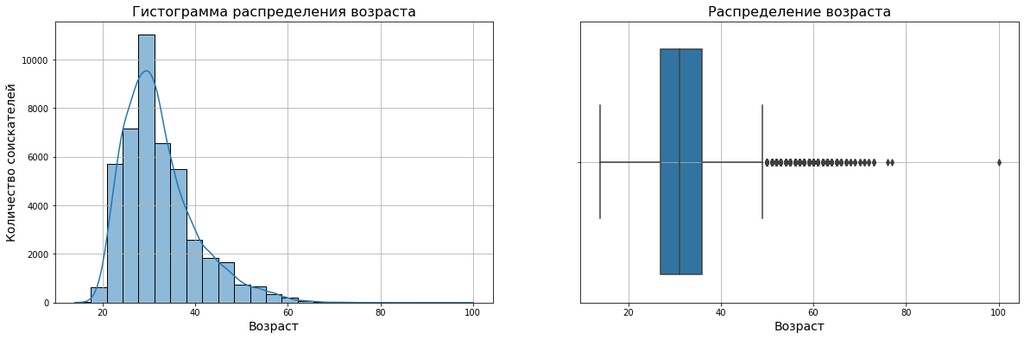

```python
HeadHunter_data_df = merged.copy()

fig, axes = plt.subplots(nrows=1, ncols=2, figsize=(20,6))
histplot = sns.histplot(
    data=HeadHunter_data_df,
    x='Возраст',
    bins=25,
    kde=True,
    ax=axes[0]
)
histplot.set_title('Гистограмма распределения возраста', fontsize=16);
histplot.set_xlabel('Возраст', fontsize=14);
histplot.set_ylabel('Количество соискателей', fontsize=14);
histplot.grid()

boxplot = sns.boxplot(
    data=HeadHunter_data_df,
    x='Возраст',
    orient='h',
    ax=axes[1]
)
boxplot.set_title('Распределение возраста', fontsize=16);
boxplot.set_xlabel('Возраст', fontsize=14);
boxplot.grid()
```

Из гистограммы распределения видно, что возраст большинства соискателей(более 10000 резюме), составляет около 30лет. Данную информацию подтверждает коробчатая диаграмма, т.к медианное значение возраста составляет 31 год. Границы распределения показывают, что предельное значение признака составляет от 14 до 48 лет. Также исходя из межквартильного размаха, можно сделать вывод, что примерный интервал возраста соискателей составляет от 27 до 36 лет. Дополнительно стоит отметить несколько аномалий. Среди них одно значение возраста составляет 100 лет, что является явной аномалией. И два значения возраста составляют 76 и 77 лет соответственно. Считаю, что данные параметры требуют дополнительного иследования.

1. Постройте распределение признака **"Опыт работы (месяц)"**. Опишите данное распределение, отвечая на следующие вопросы: чему равна мода распределения, каковы предельные значения признака, в каком примерном интервале находится опыт работы большинства соискателей? Есть ли аномалии для признака опыта работы, какие значения вы бы причислили к их числу? *Совет: постройте гистограмму и коробчатую диаграмму рядом.*

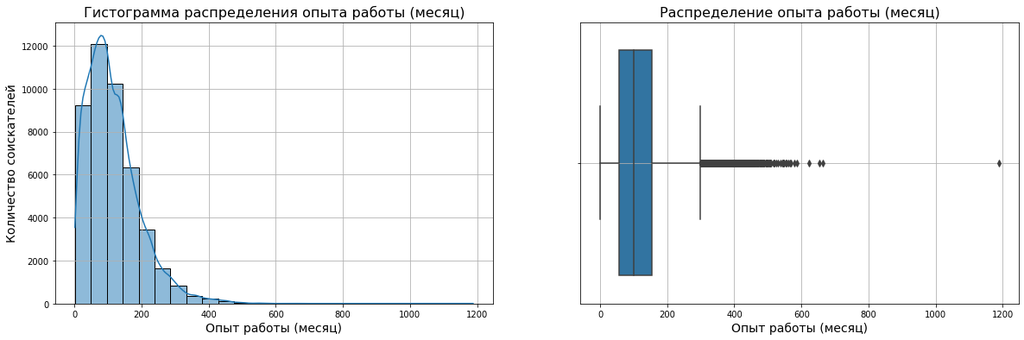

```python
HeadHunter_data_df = merged.copy()

fig, axes = plt.subplots(nrows=1, ncols=2, figsize=(20,6))
histplot = sns.histplot(
    data=HeadHunter_data_df,
    x='Опыт работы (месяц)',
    bins=25,
    kde=True,
    ax=axes[0]
)
histplot.set_title('Гистограмма распределения опыта работы (месяц)', fontsize=16);
histplot.set_xlabel('Опыт работы (месяц)', fontsize=14);
histplot.set_ylabel('Количество соискателей', fontsize=14);
histplot.grid()

boxplot = sns.boxplot(
    data=HeadHunter_data_df,
    x='Опыт работы (месяц)',
    orient='h',
    ax=axes[1]
)
boxplot.set_title('Распределение опыта работы (месяц)', fontsize=16);
boxplot.set_xlabel('Опыт работы (месяц)', fontsize=14);
boxplot.grid()
```

Из гистограммы распределения видно, что опыт большинства соискателей(более 10000 резюме), составляет от 50 до 100 мес, при этом значение моды составляет 81 мес. Данную информацию подтверждает коробчатая диаграмма, т.к медианное значение опыта составляет 100 мес. Границы распределения показывают, что предельное значение признака составляет от 0 до 300 мес. Также исходя из межквартильного размаха, можно сделать вывод, что примерный интервал возраста соискателей составляет от 57 до 154 мес. Стоит отметить аномальное значение опыта 1188 мес, данный параметр является явной аномалией, т.к. такие количество лет опыта работы значительно превышает среднюю продолжительность жизни. Дополнительно имеются несколько значений опыта более 600мес., данные значения опыта являются маловероятными и требуют дополнительного иследования.

1. Постройте распределение признака **"ЗП (руб)"**. Опишите данное распределение, отвечая на следующие вопросы: каковы предельные значения признака, в каком примерном интервале находится заработная плата большинства соискателей? Есть ли аномалии для признака возраста? Обратите внимание на гигантские размеры желаемой заработной платы. *Совет: постройте гистограмму и коробчатую диаграмму рядом.*

```
Количество соискателей требующих заработную плату выше 1 миллиона рублей составляет: 5 человек
```

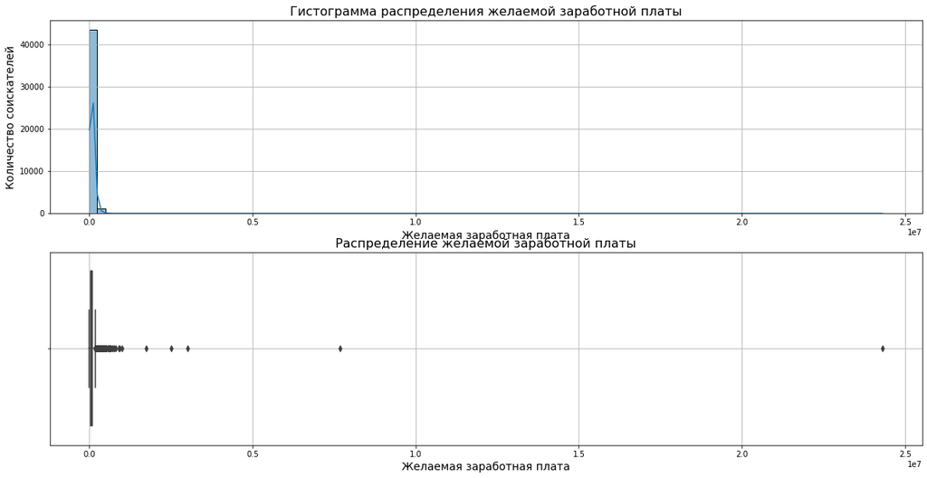

```python
HeadHunter_data_df = merged.copy()

fig, axes = plt.subplots(nrows=2, ncols=1, figsize=(20,10))
histplot = sns.histplot(
    data=HeadHunter_data_df,
    x='ЗП (руб)',
    bins=100,
    kde=True,
    ax=axes[0]
)
histplot.set_title('Гистограмма распределения желаемой заработной платы', fontsize=16);
histplot.set_xlabel('Желаемая заработная плата', fontsize=14);
histplot.set_ylabel('Количество соискателей', fontsize=14);
histplot.grid()

boxplot = sns.boxplot(
    data=HeadHunter_data_df,
    x='ЗП (руб)',
    orient='h',
    ax=axes[1]
)
boxplot.set_title('Распределение желаемой заработной платы', fontsize=16);
boxplot.set_xlabel('Желаемая заработная плата', fontsize=14);
boxplot.grid()

print('Количество соискателей требующих заработную плату выше 1 миллиона рублей составляет:',
      HeadHunter_data_df.shape[0] - HeadHunter_data_df[HeadHunter_data_df['ЗП (руб)']<=1000000].shape[0], 'человек')
```

По данным графикам невозможно сделать объективные выводы, т.к имеется как минимум одно аномальное значение желаемой заработной платы в размере около 24 млн.руб., которое сильно выбивается из общей статистики и значительно искажает оба графика. Считаю, что по данному параметру требуется предварительная очистка данных, а уже затем построение графиков с соответствующими выводами.

1. Постройте диаграмму, которая показывает зависимость **медианной** желаемой заработной платы (**"ЗП (руб)"**) от уровня образования (**"Образование"**). Используйте для диаграммы данные о резюме, где желаемая заработная плата меньше 1 млн рублей. *Сделайте выводы по представленной диаграмме: для каких уровней образования наблюдаются наибольшие и наименьшие уровни желаемой заработной платы? Как вы считаете, важен ли признак уровня образования при прогнозировании заработной платы?*

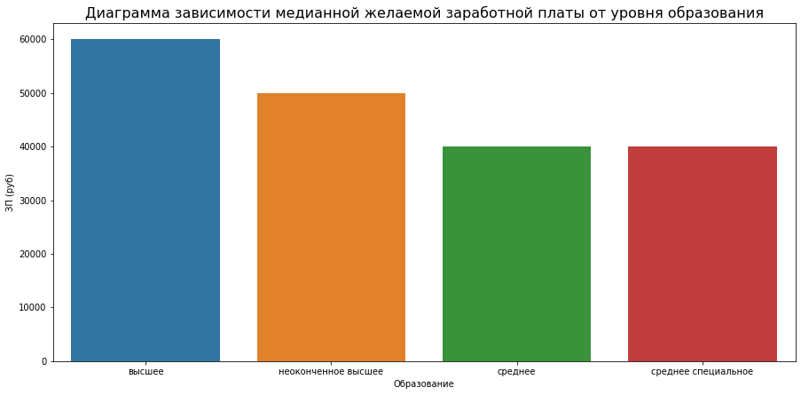

```python
grouped_data = HeadHunter_data_df[HeadHunter_data_df['ЗП (руб)']<1000000]
grouped_data = grouped_data.groupby(by='Образование').median()

fig = plt.figure(figsize=(15, 7))
barplot = sns.barplot(
    data=grouped_data,
    x=grouped_data.index,
    y='ЗП (руб)'
)
barplot.set_title('Диаграмма зависимости медианной желаемой заработной платы от уровня образования', fontsize=16);
```

Столбчатая диаграмма показывает, что чем выше уровень образование, тем уровень желаемой заработной платы выше. Уровень желаемой зароботной платы соискателей с высшим образованием в 1.5 раза выше, чем у соискателей с средним и средне специальным образованием. Я считаю, что признак уровня образования важен при прогнозировании заработной платы.

1. Постройте диаграмму, которая показывает распределение желаемой заработной платы (**"ЗП (руб)"**) в зависимости от города (**"Город"**). Используйте для диаграммы данные о резюме, где желая заработная плата меньше 1 млн рублей. *Сделайте выводы по полученной диаграмме: как соотносятся медианные уровни желаемой заработной платы и их размах в городах? Как вы считаете, важен ли признак города при прогнозировании заработной платы?*

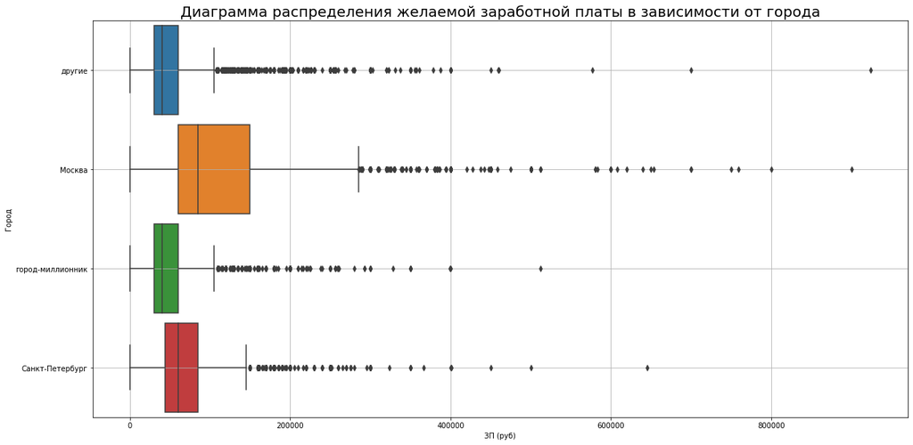

```python
grouped_data = HeadHunter_data_df[HeadHunter_data_df['ЗП (руб)']<1000000]

fig = plt.figure(figsize=(20, 10))
boxplot = sns.boxplot(
    data=grouped_data,
    y='Город',
    x='ЗП (руб)',
    orient='h',
    width=0.9
)
boxplot.grid()
boxplot.set_title('Диаграмма распределения желаемой заработной платы в зависимости от города', fontsize=20);
```

Полученная диаграмма показывает, что уровень желаемой заработной платы не зависит от размера города, так как медианные значения для городов-миллионников и для городов, где кол-во жителей менее миллиона практически одинаковы. Исключения составляют города Москва и Санкт-Петербург, где уровень желаемой заработной значительно платы выше, чем в остальных группах. Также важно отметить, что уровень желаемой заработной платы в Москве выше чем Санкт-Петербурге. Считаю,что признак города при прогнозировании заработной платы важен, особенно для городов Москва и Санкт-Петербург

1. Постройте **многоуровневую столбчатую диаграмму**, которая показывает зависимость медианной заработной платы (**"ЗП (руб)"**) от признаков **"Готовность к переезду"** и **"Готовность к командировкам"**. Проанализируйте график, сравнив уровень заработной платы в категориях.

```python
grouped_HeadHunter_data = HeadHunter_data_df.groupby(['Готовность к переезду', 'Готовность к командировкам'], as_index=False)['ЗП (руб)'].median()

fig = px.bar(
    data_frame=grouped_HeadHunter_data,
    x='Готовность к переезду',
    y='ЗП (руб)',
    color='Готовность к командировкам',
    height=500,
    width=700,
    title='Медианная з/п в зависимости от готовности к командировкам/переезду',
)
fig.update_xaxes(title_text='Готовность к переезду(True-Готов, False-Не готов)')
fig.update_yaxes(title_text='Желаемая зароботная плата(руб)')
fig.show()
```

[interactive chart not shown]

Многоуровневая столбчатая диаграмма показывает, что уровень желаемой заработной платы незначительно зависит от признаков готовности к переезду и командировкам. При готовности к переезду и командировкам уровень медианного значения желаемой заработной платы увеличивается примерно на 20% и 10%, соответственно.

1. Постройте сводную таблицу, иллюстрирующую зависимость **медианной** желаемой заработной платы от возраста (**"Возраст"**) и образования (**"Образование"**). На полученной сводной таблице постройте **тепловую карту**. Проанализируйте тепловую карту, сравнив показатели внутри групп.

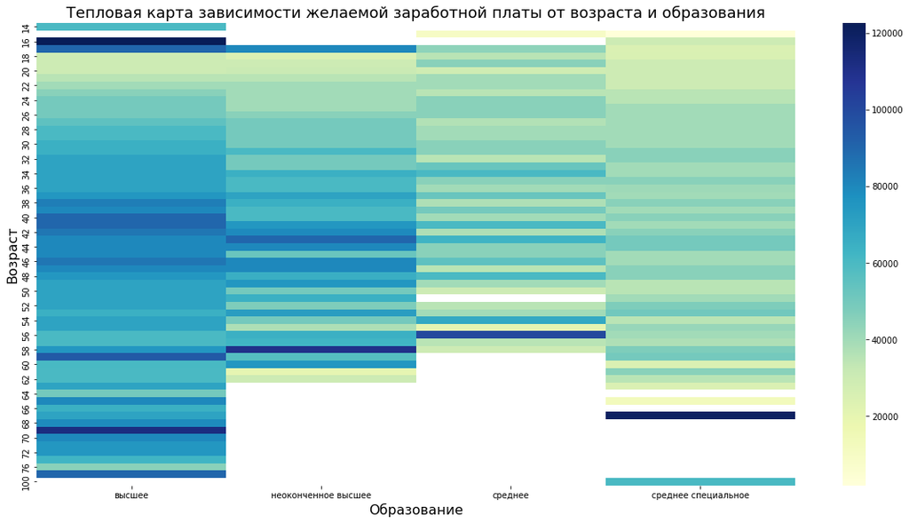

```python
pivot_HeadHunter_data_df = HeadHunter_data_df.pivot_table(
    values='ЗП (руб)',
    index='Возраст',
    columns='Образование',
    aggfunc='median'
)

fig = plt.figure(figsize=(20, 10))
heatmap=sns.heatmap(pivot_HeadHunter_data_df, cmap="YlGnBu")
heatmap.set_title('Тепловая карта зависимости желаемой заработной платы от возраста и образования', fontsize=18);
heatmap.set_ylabel('Возраст', fontsize=16);
heatmap.set_xlabel('Образование', fontsize=16);
```

Тепловая карта показывает, что у соискателей с высшим образованием желаемая зароботная плата начинает плавно увеличиваться с возраста 32 лет, достигает пика около 40 лет, и далее заметно незначительное снижение. У группы с неоконченным высшим образованием, картина распределения возраста желаемой зароботной платы примерно соответствует группе с высшим образованием, где пик достигается около 42 лет, но при этом требования к заработной плате немного ниже. Также можно заметить аномальные значения у лиц с высшим образованием в возрастной группе с 14 до 18лет и в возрастной группе 69 лет и старше. Данные значения скорее всего являются выбросами, т.к. получить высшее образование до 18 лет практически не возможно, а возрастная группа 69 лет и старше очень редко является трудоспособной. У группы с неоконченным высшим образованием наблюдаются выбросы для возрастной группы 16-18 лет.  
У группы с средним специальным образованием имеются выбросы для возрастной категории около 66лет.  
По тепловой карте хорошо видно, что с увеличением уровня образования, требования к желаемой зароботной плате и трудоспособный возраст увеличиваются.

1. Постройте **диаграмму рассеяния**, показывающую зависимость опыта работы (**"Опыт работы (месяц)"**) от возраста (**"Возраст"**). Опыт работы переведите из месяцев в года, чтобы признаки были в едином масштабе. Постройте на графике дополнительно прямую, проходящую через точки (0, 0) и (100, 100). Данная прямая соответствует значениям, когда опыт работы равен возрасту человека. Точки, лежащие на этой прямой и выше нее - аномалии в наших данных (опыт работы больше либо равен возрасту соискателя)

```python
import plotly.graph_objects as go


scatter_data = HeadHunter_data_df.copy()
scatter_data['Опыт работы (год)'] = round(scatter_data['Опыт работы (месяц)']/12, 2)

fig1 = go.Figure(data=go.Scatter(x=[0,100], y=[0,100], mode='lines+markers', line_color='red'))
fig2 = px.scatter(scatter_data, x="Возраст", y="Опыт работы (год)", title='Диаграмма зависимости опыта работы от возраста')
fig = go.Figure(data = fig1.data + fig2.data)
fig.update_xaxes(title_text='Возраст')
fig.update_yaxes(title_text='Опыт работы (год)')
fig.show()
```

[interactive chart not shown]

Данная диаграмма показывает, что 7 соискателей в резюме указали опыт работы превышающий их собственный возраст. Эти данные явно являются выбросами

**Дополнительные баллы**

Для получения 2 дополнительных баллов по разведывательному анализу постройте еще два любых содержательных графика или диаграммы, которые помогут проиллюстрировать влияние признаков/взаимосвязь между признаками/распределения признаков. Приведите выводы по ним. Желательно, чтобы в анализе участвовали признаки, которые мы создавали ранее в разделе "Преобразование данных".

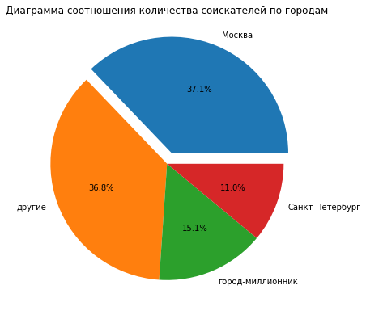

```python
pie_data = HeadHunter_data_df['Город'].value_counts()

fig = plt.figure(figsize=(5,5))
axes = fig.add_axes([0,0,1,1])
axes.pie(
    pie_data,
    labels=pie_data.index,
    explode=[0.1, 0, 0, 0],
    autopct='%.1f%%'
)
title= axes.set_title('Диаграмма соотношения количества соискателей по городам')
```

Круговая диаграмма показывает, что большая часть соискателей интересуются работой в городе Москва. Дополнительно можно увидеть подозрительно низкий спрос на работу в Санк-Петербурге.

```python
grouped_HeadHunter_data = HeadHunter_data_df.groupby(['Пол', 'Город'], as_index=False)['ЗП (руб)'].median()

fig = px.bar(
    data_frame=grouped_HeadHunter_data,
    x='Город',
    y='ЗП (руб)',
    color='Пол',
    height=500,
    width=700,
    title='Диаграмма желаемой заработной платы в зависимости от пола и города',
)
fig.update_xaxes(title_text='Город')
fig.update_yaxes(title_text='Желаемая заработная плата(руб)')
fig.show()
```

[interactive chart not shown]

Диаграмма показывает, что медианная желаемая зарплата мужчин во всех городах превышает зарплату женщин в среднем 20 т.руб для города Москвы и 10 т.руб для остальных городов.

# Очистка данных

1. Начнем с дубликатов в наших данных. Найдите **полные дубликаты** в таблице с резюме и удалите их.

```python
dupl_columns = list(HeadHunter_data_df.columns)
mask = HeadHunter_data_df.duplicated(subset=dupl_columns)
HeadHunter_duplicates = HeadHunter_data_df[mask]
print(f'Число найденных дубликатов: {HeadHunter_duplicates.shape[0]}')
HeadHunter_dedupped = HeadHunter_data_df.drop_duplicates(subset=dupl_columns)
print(f'Результирующее число записей: {HeadHunter_dedupped.shape[0]}')
```

```
Число найденных дубликатов: 161
Результирующее число записей: 44583
```

1. Займемся пропусками. Выведите информацию **о числе пропусков** в столбцах.

```python
HeadHunter_isnull = HeadHunter_dedupped.isnull()
print(HeadHunter_isnull['Опыт работы (месяц)'].value_counts())
print('Количество пропусков в столбце «Опыт работы (месяц)»:', HeadHunter_isnull[HeadHunter_isnull['Опыт работы (месяц)'] == True].shape[0])
```

```
False    44415
True       168
Name: Опыт работы (месяц), dtype: int64
Количество пропусков в столбце «Опыт работы (месяц)»: 168
```

1. Итак, у нас есть пропуски в 3ех столбцах: **"Опыт работы (месяц)"**, **"Последнее/нынешнее место работы"**, **"Последняя/нынешняя должность"**. Поступим следующим образом: удалите строки, где есть пропуск в столбцах с местом работы и должностью. Пропуски в столбце с опытом работы заполните **медианным** значением.

```python
fill_data = HeadHunter_dedupped.copy()

values = {
    'Опыт работы (месяц)':fill_data['Опыт работы (месяц)'].median()
}
fill_data = fill_data.fillna(values)
drop_data = fill_data.copy()
drop_data = drop_data.dropna(how='any', axis=0)
print('Результирующее среднее значение в столбце «Опыт работы (месяц)»:', round(drop_data['Опыт работы (месяц)'].mean()))
```

```
Результирующее среднее значение в столбце «Опыт работы (месяц)»: 114
```

1. Мы добрались до ликвидации выбросов. Сначала очистим данные вручную. Удалите резюме, в которых указана заработная плата либо выше 1 млн. рублей, либо ниже 1 тыс. рублей.

```python
outliers = drop_data[(drop_data['ЗП (руб)']>1000000) | (drop_data['ЗП (руб)']<1000)]
cleaned = drop_data.drop(outliers.index, axis=0)
print('Результирующее число записей:', cleaned.shape[0])
print('Количество выбросов:', outliers.shape[0])
```

```
Результирующее число записей: 44492
Количество выбросов: 89
```

1. В процессе разведывательного анализа мы обнаружили резюме, в которых **опыт работы в годах превышал возраст соискателя**. Найдите такие резюме и удалите их из данных

```python
outliers = drop_data[(drop_data['Опыт работы (месяц)']/12)>(drop_data['Возраст'])]
cleaned = cleaned.drop(outliers.index, axis=0)
print('Результирующее число записей:', cleaned.shape[0])
print('Количество выбросов:', outliers.shape[0])
```

```
Результирующее число записей: 44485
Количество выбросов: 7
```

1. В результате анализа мы обнаружили потенциальные выбросы в признаке **"Возраст"**. Это оказались резюме людей чересчур преклонного возраста для поиска работы. Попробуйте построить распределение признака в **логарифмическом масштабе**. Добавьте к графику линии, отображающие **среднее и границы интервала метода трех сигм**. Напомним, сделать это можно с помощью метода axvline. Например, для построение линии среднего будет иметь вид:

`histplot.axvline(log_age.mean(), color='k', lw=2)`

В какую сторону асимметрично логарифмическое распределение? Напишите об этом в комментарии к графику. Найдите выбросы с помощью метода z-отклонения и удалите их из данных, используйте логарифмический масштаб. Давайте сделаем послабление на **1 сигму** (возьмите 4 сигмы) в **правую сторону**.

Выведите таблицу с полученными выбросами и оцените, с каким возрастом соискатели попадают под категорию выбросов?

```
Число выбросов по методу z-отклонения: 3
Результирующее число записей: 44482
```

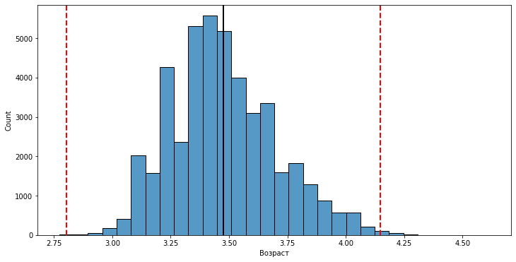

```python
fig, ax = plt.subplots(1, 1, figsize=(12, 6))
log_age = np.log(cleaned['Возраст'] +1 )
histplot = sns.histplot(data=log_age, bins=30, ax=ax)
histplot.axvline(log_age.mean(), color='k', lw=2)
histplot.axvline(log_age.mean()+3*log_age.std(), color='red', lw=2, ls='--')
histplot.axvline(log_age.mean()-3*log_age.std(), color='red', lw=2, ls='--')

def outliers_z_score_mod(data, feature, left=3, right=3, log_scale=False):
    if log_scale:
        x = np.log(data[feature]+1)
    else:
        x = data[feature]
    mu = x.mean()
    sigma = x.std()
    lower_bound = mu - left*sigma
    upper_bound = mu + right*sigma
    outliers = data[(x<lower_bound) | (x>upper_bound)]
    cleaned = data[(x>lower_bound) & (x<upper_bound)]
    return outliers, cleaned

outliers, cleaned = outliers_z_score_mod(cleaned, 'Возраст', 3, 4, log_scale=True)
print(f'Число выбросов по методу z-отклонения: {outliers.shape[0]}')
print(f'Результирующее число записей: {cleaned.shape[0]}')
```

Диаграмма показывает, что среднее значение (жирная вертикальная линия) находится правее моды, это свойство распределений с правостороней асимметрией. Также видны наблюдения, которые мы не захватили своим интервалом (два маленьких пенька правее верхней границы) — это и есть выбросы соответствующие значениям приближенным к значению 100лет. По методу z-отклонения с правой границей соответствующей 4 сигмы выбросов оказалось 3